# The Double two-piece Sinh-Arcsinh distribution

[F. Javier Rubio](https://sites.google.com/site/fjavierrubio67/)

May 16, 2020

# Two-Piece Scale and Shape Transformations

Let ${\mathcal F}$ be the family of continuous, unimodal, symmetric densities $\tilde f(\cdot;\mu,\sigma,\delta)$ with support on ${\mathbb R}$ and with mode and location parameter $\mu\in{\mathbb R}$, scale parameter $\sigma\in{\mathbb R}_+$, and shape parameter $\delta\in\Delta\subset{\mathbb R}$. A shape parameter is anything that is not a location or a scale parameter.

Denote $\tilde f(x;\mu,\sigma,\delta)=\dfrac{1}{\sigma}\tilde f\left(\dfrac{x-\mu}{\sigma};0,1,\delta\right)\equiv\dfrac{1}{\sigma}f\left(\dfrac{x-\mu}{\sigma};\delta\right)$. Distribution functions are denoted by the corresponding uppercase letters. We define the two-piece probability density function constructed of $f(x;\mu,\sigma_1,\delta_1)$ truncated to $(-\infty,\mu)$ and $f(x;\mu,\sigma_2,\delta_2)$ truncated to $[\mu,\infty)$:
$$s(x;\mu,\sigma_1,\sigma_2,\delta_1,\delta_2) = \dfrac{2\varepsilon }{\sigma_1}f\left(\dfrac{x-\mu}{\sigma_1};\delta_1\right)I(x<\mu) + \dfrac{2(1-\varepsilon) }{\sigma_2}f\left(\dfrac{x-\mu}{\sigma_2};\delta_2\right)I(x\geq\mu),$$
where we achieve a continuous density function if we choose
$$\varepsilon = \dfrac{\sigma_1 f(0;\delta_2)}{\sigma_1 f(0;\delta_2)+\sigma_2 f(0;\delta_1)}.$$
This family of distributions is referred to as the family of Double Two-Piece (DTP) family of distributions (Rubio and Steel 2015). The corresponding cumulative distribution function is then given by
$$\begin{aligned}
S(x;\mu,\sigma_1,\sigma_2,\delta_1,\delta_2) &= 2\varepsilon F\left(\dfrac{x-\mu}{\sigma_1};\delta_1\right)I(x<\mu)\\
&+ \left\{\varepsilon +(1-\varepsilon)\left[2F\left(\dfrac{x-\mu}{\sigma_2};\delta_2\right)-1\right]\right\}I(x\geq\mu).
\end{aligned}$$
The quantile function can be obtained by inverting the CDF. These functions are implemented in the [DTP R package](https://rpubs.com/FJRubio/DTP). By construction, this density is continuous, unimodal with mode at $\mu$, and the amount of mass to the left of its mode is given by $S(\mu;\mu,\sigma_1,\sigma_2,\delta_1,\delta_2)=\varepsilon$. This transformation preserves the ease of use of the original distribution $f$ and allows $s$ to have different shapes in each direction, dictated by $\delta_1$ and $\delta_2$. In addition, by varying the ratio $\sigma_1/\sigma_2$, we control the allocation of mass on either side of the mode.

# The DTP Sinh-Arcsinh (SAS) distribution

The [Sinh-Arcsinh distribution](https://rpubs.com/FJRubio/SAS) (Jones and Pewsey 2009) is a flexible 4-parameter distribution that can account for varying tail behaviour as well as asymmetry. Rubio, Ogundimu, and Hutton (2016) showed that the asymmetry levels obtained by this distribution are limited, and proposed introducing skewness by means of the two-piece transformation (Rubio and Steel 2020) (see [TPSAS Package](https://rpubs.com/FJRubio/TPSAS)). In order to capture different tails and scale on each side of the mode, Rubio and Steel (2015) proposed a distribution obtained by transforming the symmetric Sinh-Arcsinh distribution using the DTP construction described in the previous section. This is, the baseline distribution is the symmetric SAS distribution (Jones and Pewsey 2009,rubio:2015):
$$f(x;\delta) = {\delta}\phi\left[\sinh\left(\delta \operatorname{arcsinh}\left(x\right)\right)\right] \dfrac{\cosh\left(\delta \operatorname{arcsinh}\left(x\right)\right)}{\sqrt{1+x^2}},$$
where $\phi(x) = \dfrac{1}{\sqrt{2\pi}}\exp\left\{-\dfrac{x^2}{2} \right\}$. The implementation of the pdf, cdf, quantile function, and random number generation can be done using the DTP R package as illustrate below.

# DTP SAS pdf, cdf, quantile, and RNG

```r
#####################################################################
# mu       : location parameter
# sigma1   : scale parameter 1
# sigma1   : scale parameter 1
# delta1   : shape parameter 1
# delta2   : shape parameter 2
#####################################################################
# Required package
#
library(DTP)
#********************************************************************************
# Baseline functions
#********************************************************************************
# baseline symmetric SAS pdf
dsas0 <- function(x,delta,log=FALSE){
         logPDF <- dnorm(sinh(delta*asinh(x)),log=T) + log(delta) + log(cosh(delta*asinh(x))) -0.5*log(1+x^2)
  ifelse( is.numeric(logPDF),ifelse( log, return(logPDF), return(exp(logPDF)) ), logPDF )
}

# baseline symmetric SAS cdf
psas0 <- function(x,delta,log.p=FALSE){
         logCDF <- pnorm(sinh(delta*asinh(x)),log.p=T)
  ifelse( is.numeric(logCDF),ifelse( log.p, return(logCDF), return(exp(logCDF)) ), logCDF )
}

# baseline quantile function
qsas0 <- function(p,delta){
         Q <- sinh((asinh(qnorm(p)))/delta)
  return(Q)
}

# baseline RNG
rsas0 <- function(n,delta){
         sample <- sinh((asinh(rnorm(n)))/delta)
  return(sample)
}

#********************************************************************************
# DTP SAS functions
#********************************************************************************
# Probability Density Function
ddtpsas <- function(x, mu, sigma1, sigma2, delta1, delta2, log = FALSE){
out <- ddtp(x, mu, sigma1, sigma2, delta1, delta2, dsas0, param = "tp", log = log)
return(out)
}

# Cumulative Distribution Function
pdtpsas <- function(x, mu, sigma1, sigma2, delta1, delta2, log.p = FALSE){
  out <- pdtp(x, mu, sigma1, sigma2, delta1, delta2, psas0, dsas0, param = "tp", log = FALSE)
  return(out)
}

# Quantile Function
qdtpsas <- function(x, mu, sigma1, sigma2, delta1, delta2, log.p = FALSE){
  out <- qdtp(x, mu, sigma1, sigma2, delta1, delta2, rsas0, dsas0, param = "tp", log = FALSE)
  return(out)
}

# RNG Function
rdtpsas <- function(x, mu, sigma1, sigma2, delta1, delta2, log.p = FALSE){
  out <- rdtp(x, mu, sigma1, sigma2, delta1, delta2, rsas0, dsas0, param = "tp")
  return(out)
}
```

# Illustrations

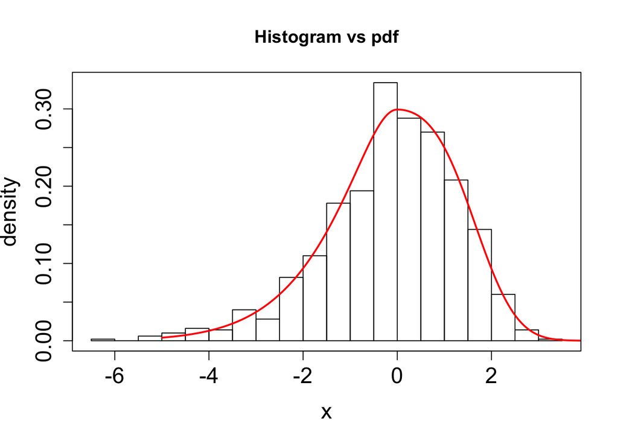

```r
####################################################
# Illustrations
####################################################

# Simulated data
set.seed(123)
data <- rdtpsas(1000,0,1,2,0.75,1.5)
# True pdf
pdf.true <- Vectorize(function(x) ddtpsas(x,0,1,2,0.75,1.5))
# True cdf
cdf.true <- Vectorize(function(x) pdtpsas(x,0,1,2,0.75,1.5))


# Histogram vs pdf
hist(data, breaks = 30, probability = T, cex.axis = 1.5, cex.lab = 1.5,
     xlab = "x", ylab = "density", main = "Histogram vs pdf")
curve(pdf.true, -5,15, add= T, col="red", lwd = 2, n = 1000)
box()
```

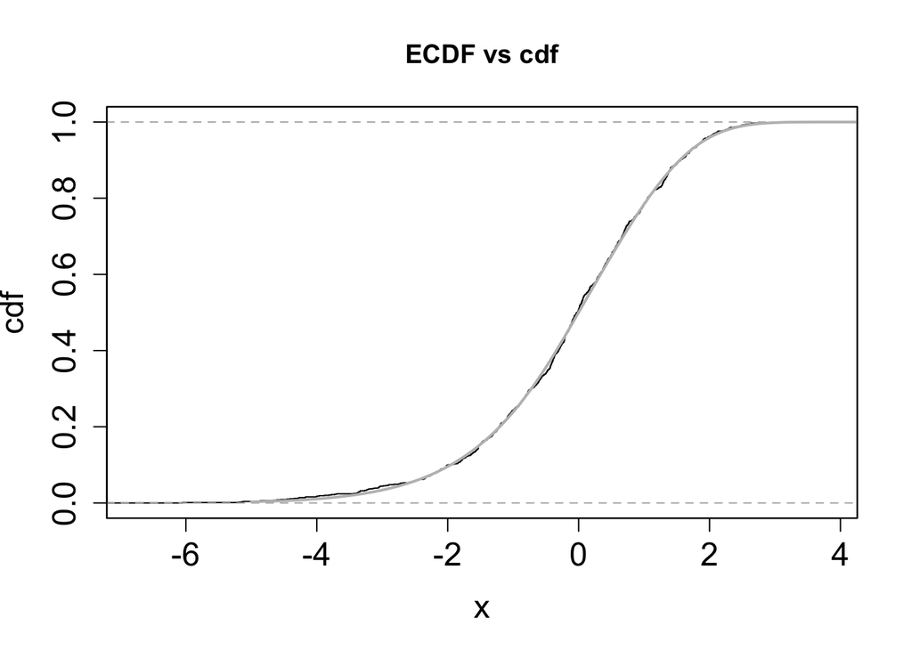

```r
# ECDF vs cdf
plot(ecdf(data), cex.axis = 1.5, cex.lab = 1.5,
     xlab = "x", ylab = "cdf", main = "ECDF vs cdf")
curve(cdf.true, -5,15, add= T, col="gray", lwd = 2, n = 1000)
box()
```

# References

Jones, M.C., and A. Pewsey. 2009. “Sinh-Arcsinh Distributions.” *Biometrika* 96 (4): 761–80.

Rubio, F.J., E.O. Ogundimu, and J.L. Hutton. 2016. “On Modelling Asymmetric Data Using Two-Piece Sinh–Arcsinh Distributions.” *Brazilian Journal of Probability and Statistics*, 485–501.

Rubio, F.J., and M.F.J. Steel. 2015. “Bayesian Modelling of Skewness and Kurtosis with Two-Piece Scale and Shape Distributions.” *Electronic Journal of Statistics* 9 (2): 1884–1912.

———. 2020. “The Family of Two-Piece Distributions.” *Significance* 17 (1): 12–13.